# Prosper - Exploratory data analysis with R

jaroslav klen

January 14, 2016

## Goal of analysis

Question, to which I would like to find answer with this exploratory data analysis, is if there are any input variables, which have a relationship to borrower’s ability to repay loan?

#### Variable description

https://www.prosper.com/Downloads/Services/Documentation/ProsperDataExport_Details.html

## Dataset consistency and pre-investigations

This part is focused on examining structure of the dataset, characteristics and meanings of variables neccessary to perform analysis. Goal is to have dataset analysis-ready together with newly created variables, which provide us more information about loan listing or borrower. 2nd goal is finding or creating target variables, which express borrower’s ability to repay loan, to which I would like to create regression model from input variables, if possible.

According to provided variables description, ListingKey, ListingNumber and LoanKey are all unique identifiers of each listing included in dataset. Lets check it.

Number of loans in whole dataset : 113937

Unique number of ListingKey: 113066

Unique number of ListingNumber: 113066

Unique number of LoanKey: 113066

Number of duplicated rows: 0

For purpose of further analysis, 871 duplicate listings (based on LisingKey) with higher row index were removed. For unknown reason, they differ on ProsperScore. Prior performing any analysis, we have to examine the structure of the dataset to be sure, that all variables are in proper format and if information they contain is consistent.

Summary of IncomeRange:

```
##             $0      $1-24,999      $100,000+ $25,000-49,999 $50,000-74,999
##            621           7241          17188          31940          30749
## $75,000-99,999  Not displayed   Not employed
##          16780           7741            806
```

Summary of EmploymentStatus:

```
##                    Employed     Full-time Not available  Not employed
##          2255         66598         26354          5347           835
##         Other     Part-time       Retired Self-employed
##          3742          1088           795          6052
```

Number of loans, which have IncomeRange and EmploymentStatus ‘Not employed’: 806

Category ‘Not employed’ in variable IncomeRange we can replace with NA, because this information is probably included in variable EmploymentStatus, for category ‘Not displayed’ we have to create new variable called IncomeDisplayed with values 0 or 1 and replace it in original variable with NA. We have to change empty string and ‘Not available’ category in EmploymentStatus variable to NA too. Altough, these values could maybe reflect some changes of internal processes during loan listing evaluation, without knowing more information it is better this solution.

Since Prosper got through major changes in business model and its relaunch on July 2009, it might be possible, that I will use use these data only in further analysis, but for now, I will use all data.

Modified dataset structure:

```
## 'data.frame':    113066 obs. of  82 variables:
##  $ ListingKey                         : chr  "1021339766868145413AB3B" "10273602499503308B223C1" "0EE9337825851032864889A" "0EF5356002482715299901A" ...
##  $ ListingNumber                      : int  193129 1209647 81716 658116 909464 1074836 750899 768193 1023355 587746 ...
##  $ ListingCreationDate                : POSIXct, format: "2007-08-26 19:09:29" "2014-02-27 08:28:07" ...
##  $ CreditGrade                        : Ord.factor w/ 8 levels "AA"<"A"<"B"<"C"<..: 4 NA 7 NA NA NA NA NA NA NA ...
##  $ Term                               : Factor w/ 3 levels "12","36","60": 2 2 2 2 2 3 2 2 2 3 ...
##  $ LoanStatus                         : Ord.factor w/ 11 levels "Completed"<"FinalPaymentInProgress"<..: 1 3 1 3 3 3 3 3 3 3 ...
##  $ ClosedDate                         : POSIXct, format: "2009-08-14" NA ...
##  $ BorrowerAPR                        : num  0.165 0.12 0.283 0.125 0.246 ...
##  $ BorrowerRate                       : num  0.158 0.092 0.275 0.0974 0.2085 ...
##  $ LenderYield                        : num  0.138 0.082 0.24 0.0874 0.1985 ...
##  $ EstimatedEffectiveYield            : num  NA 0.0796 NA 0.0849 0.1832 ...
##  $ EstimatedLoss                      : num  NA 0.0249 NA 0.0249 0.0925 ...
##  $ EstimatedReturn                    : num  NA 0.0547 NA 0.06 0.0907 ...
##  $ ProsperRating_numeric              : Ord.factor w/ 7 levels "1"<"2"<"3"<"4"<..: NA 6 NA 6 3 5 2 4 7 4 ...
```

[output cut: 68 more lines]

MemberKey variable should be unique identifier of loan applicant. Lets see how many unique users applied for a loan and lets check also TotalProsperLoans variable, which shows number of previous succesfuly repaid prosper loans of the applicant at the time when listing was created.

Number of unique borrowers: 90347

Summary of TotalProsperLoans:

```
##     0     1     2     3     4     5     6     7     8  NA's
##     1 15342  4457  1420   408    99    28     8     1 90399
```

```
## [1] "--- % ---"
```

```
##     0     1     2     3     4     5     6     7     8  NA's
##  0.00 13.68  3.97  1.27  0.36  0.09  0.02  0.01  0.00 80.60
```

We see, that most of the loans are currently from first time borrowers, but lets examine LoanStatus and LoanCurrentDaysDelinquent.

```
## [1] "1   100 %  ---  ld.LoanStatus"
##              Completed FinalPaymentInProgress                Current
##                  37164                    203                  55730
##   Past Due (1-15 days)  Past Due (16-30 days)  Past Due (31-60 days)
##                    800                    265                    361
##  Past Due (61-90 days) Past Due (91-120 days)   Past Due (>120 days)
##                    311                    304                     16
##              Defaulted             Chargedoff                   NA's
##                   5016                  11992                      1
## [1] "-- % --"
##              Completed FinalPaymentInProgress                Current
##                  33.13                   0.18                  49.69
##   Past Due (1-15 days)  Past Due (16-30 days)  Past Due (31-60 days)
##                   0.71                   0.24                   0.32
##  Past Due (61-90 days) Past Due (91-120 days)   Past Due (>120 days)
##                   0.28                   0.27                   0.01
##              Defaulted             Chargedoff                   NA's
##                   4.47                  10.69                   0.00
```

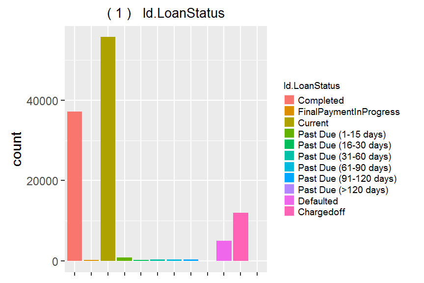

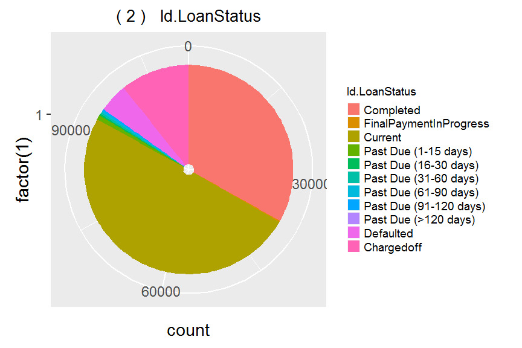

```
## [1] "1   100 %  ---  LoanCurrentDaysDelinquent"
##    Min. 1st Qu.  Median    Mean 3rd Qu.    Max.
##     1.0   207.0   604.0   913.2  1698.0  2704.0
```

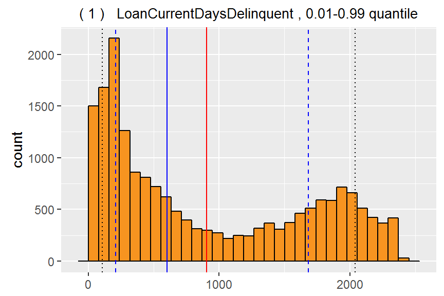

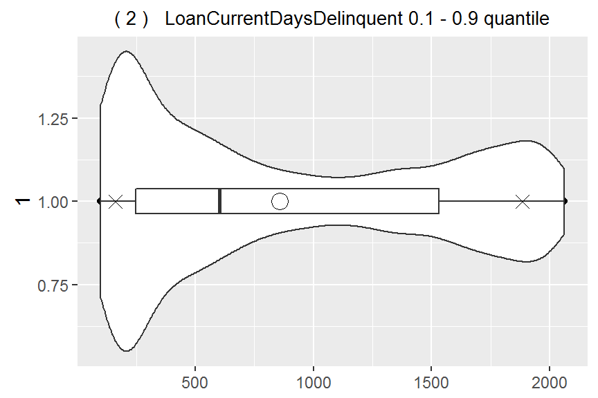

83 percent of all loans are 0 days delinquent. Distribution of delinquent days of remaining loans is bimodal. The 2nd mode, around 2000 days is interesting, because it suggest, that in years 2008 - 2009 prosper issued more loans, which are until time when this dataset was created, unrepaid. Decrease between 1000 - 2000 days is probably in relation with change of prosper business model in middle of 2009.

We see as well, that around half of all loans in dataset are current outstanding loans, and around 1/3 are completed. Defaulted and charged off loans make 15.16 percent.

Summary of LoanCurrenDaysDelinquent by LoanStatus:

```
## ld$LoanStatus: Completed
##    Min. 1st Qu.  Median    Mean 3rd Qu.    Max.
##       0       0       0       0       0       0
## --------------------------------------------------------
## ld$LoanStatus: FinalPaymentInProgress
##    Min. 1st Qu.  Median    Mean 3rd Qu.    Max.
##       0       0       0       0       0       0
## --------------------------------------------------------
## ld$LoanStatus: Current
##    Min. 1st Qu.  Median    Mean 3rd Qu.    Max.
##       0       0       0       0       0       0
## --------------------------------------------------------
## ld$LoanStatus: Past Due (1-15 days)
##     Min.  1st Qu.   Median     Mean  3rd Qu.     Max.
##  1.00000  4.00000  9.00000  7.80125 10.00000 15.00000
## --------------------------------------------------------
## ld$LoanStatus: Past Due (16-30 days)
##    Min. 1st Qu.  Median    Mean 3rd Qu.    Max.
## 16.0000 19.0000 22.0000 22.1283 25.0000 30.0000
## --------------------------------------------------------
## ld$LoanStatus: Past Due (31-60 days)
##     Min.  1st Qu.   Median     Mean  3rd Qu.     Max.
## 31.00000 39.00000 44.00000 45.54848 52.00000 60.00000
## --------------------------------------------------------
## ld$LoanStatus: Past Due (61-90 days)
##     Min.  1st Qu.   Median     Mean  3rd Qu.     Max.
## 61.00000 69.50000 75.00000 75.67846 83.00000 90.00000
## --------------------------------------------------------
## ld$LoanStatus: Past Due (91-120 days)
##     Min.  1st Qu.   Median     Mean  3rd Qu.     Max.
##  91.0000 100.0000 104.5000 105.5099 113.0000 120.0000
## --------------------------------------------------------
## ld$LoanStatus: Past Due (>120 days)
##    Min. 1st Qu.  Median    Mean 3rd Qu.    Max.
##   121.0   121.0   121.0   121.5   121.0   129.0
## --------------------------------------------------------
## ld$LoanStatus: Defaulted
##      Min.   1st Qu.    Median      Mean   3rd Qu.      Max.
##    1.0000  175.0000  249.0000  451.2271  552.0000 2421.0000
## --------------------------------------------------------
## ld$LoanStatus: Chargedoff
##     Min.  1st Qu.   Median     Mean  3rd Qu.     Max.
##  121.000  507.750 1389.000 1255.961 1927.000 2704.000
```

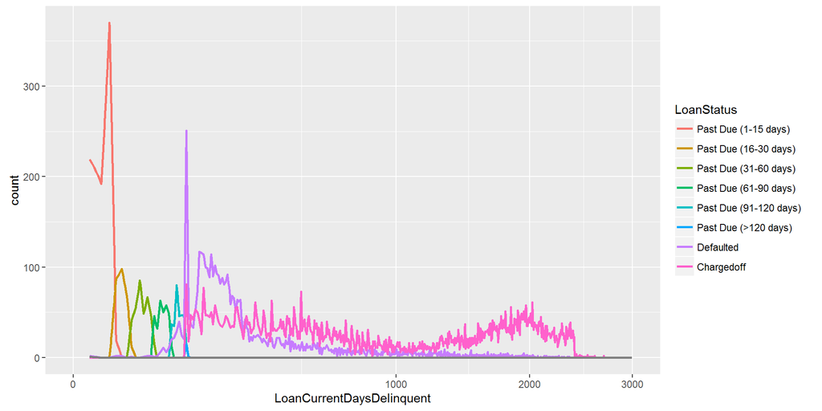

A loan should have defaulted status based on number of delinquent days, and it should be charged off after default and when there is no reasonable chance, that the borrower will repay the loan. From above frequency polygons and summary we see, that 6x PastDue loan status is an interval representation of current number of deliquent days, which is not the case for defaulted (minimum 1, growth starting at 60) and charged off loans (minimum and growth at 121). Other interesting thing is the big peak of defaulted loans at 120 deliquent days and very low count of >120 category. This category is currently probably not used and instead, loans reaching 120 delinquent days are moved into defaulted category. For clarification, we see state of outstanding delinquent listings at the time when this dataset was created, around 2014-03-17.

```
## [1] "1   14.29 %  ---  Term"
##    12    36    60
##  1564 86501 24098
## [1] "-- % --"
##    12    36    60
##  1.39 77.12 21.48
```

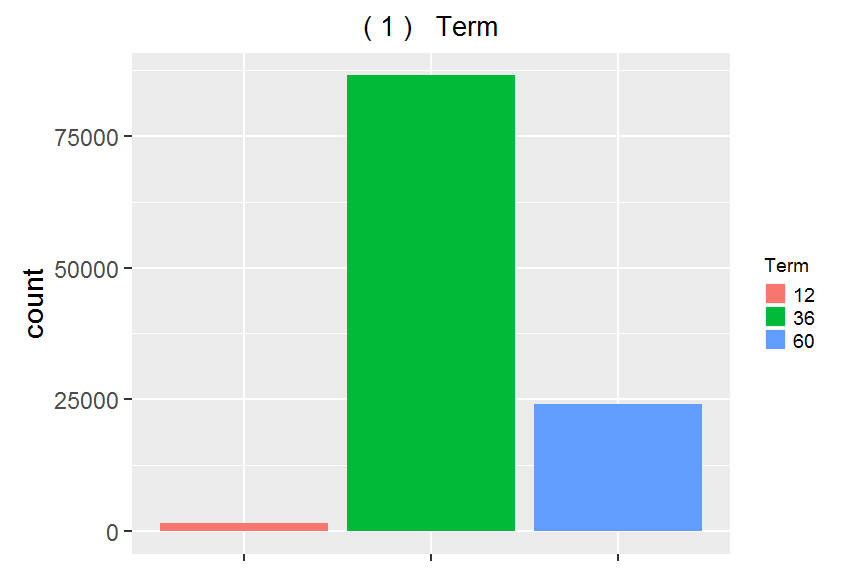

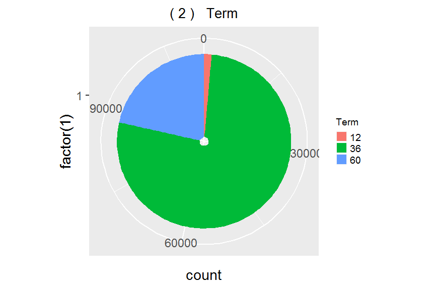

```
## [1] "2   28.57 %  ---  ClosedDate"
##                  Min.               1st Qu.                Median
## "2005-12-28 00:00:00" "2009-07-15 00:00:00" "2011-03-31 00:00:00"
##                  Mean               3rd Qu.                  Max.
## "2011-03-07 12:30:28" "2013-01-29 00:00:00" "2014-03-10 00:00:00"
##                  NA's
##               "57990"
```

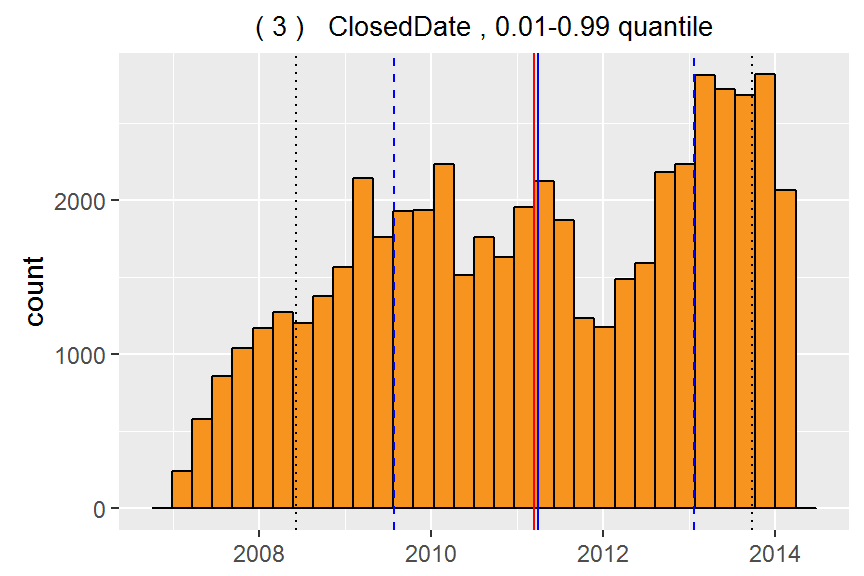

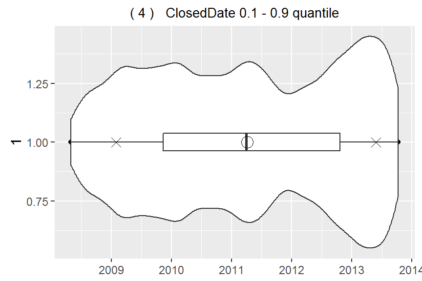

```
## [1] "3   42.86 %  ---  LoanOriginalAmount"
##    Min. 1st Qu.  Median    Mean 3rd Qu.    Max.
##    1000    4000    6500    8328   12000   35000
```

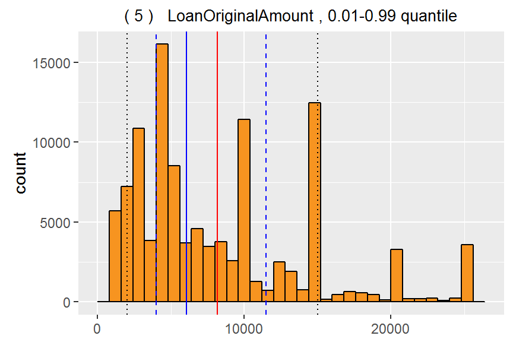

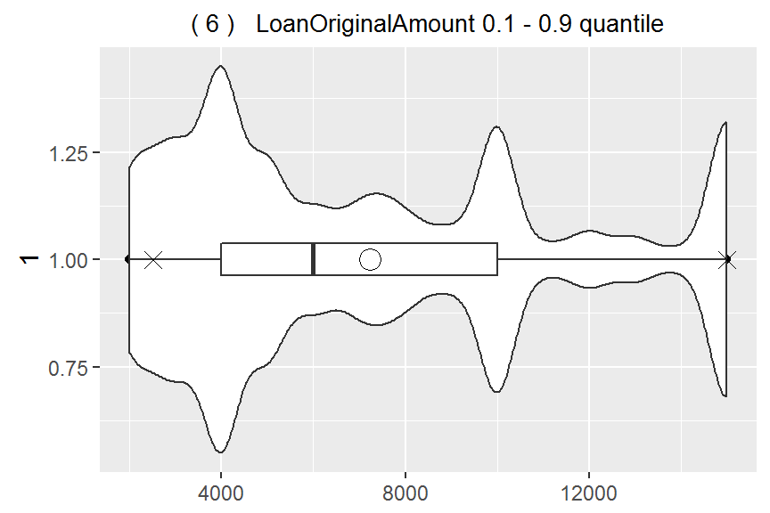

```
## [1] "4   57.14 %  ---  LoanOriginationDate"
##                  Min.               1st Qu.                Median
## "2005-11-22 00:00:00" "2008-09-29 00:00:00" "2012-06-21 00:00:00"
##                  Mean               3rd Qu.                  Max.
## "2011-07-15 10:57:13" "2013-09-12 00:00:00" "2014-03-12 00:00:00"
```

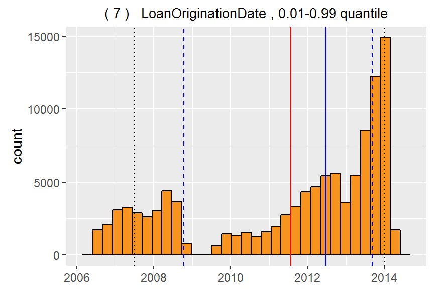

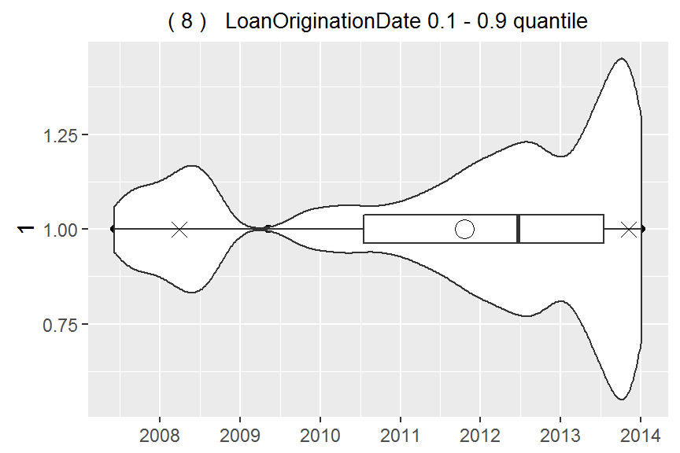

```
## [1] "5   71.43 %  ---  MonthlyLoanPayment"
##    Min. 1st Qu.  Median    Mean 3rd Qu.    Max.
##     0.0   131.4   217.7   272.2   370.6  2252.0
```

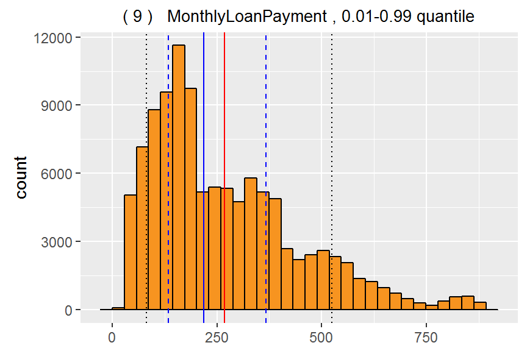

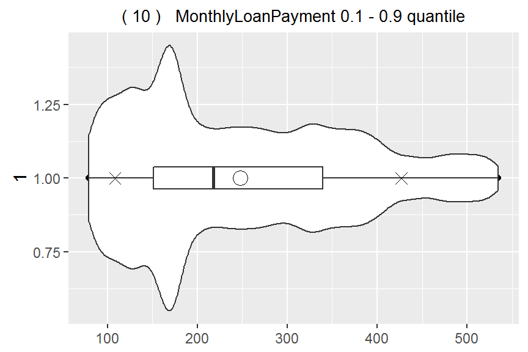

```
## [1] "6   85.71 %  ---  LP_CustomerPrincipalPayments"
##    Min. 1st Qu.  Median    Mean 3rd Qu.    Max.
##     0.0   506.7  1590.0  3097.0  4000.0 35000.0
```

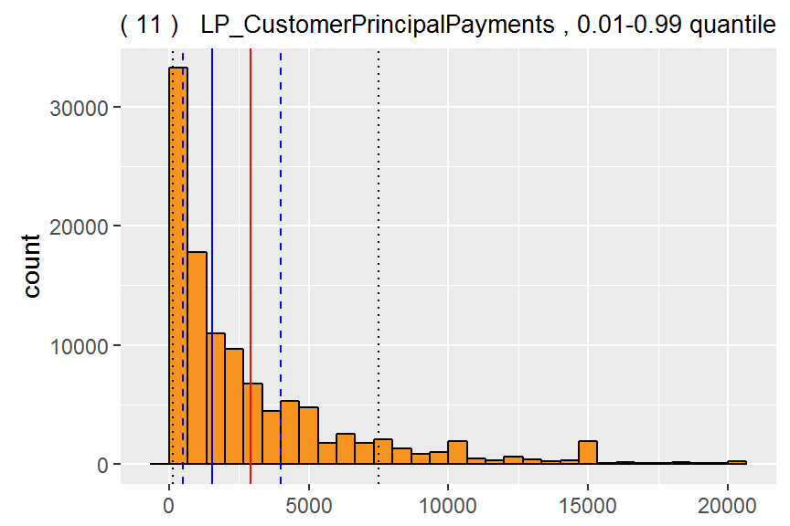

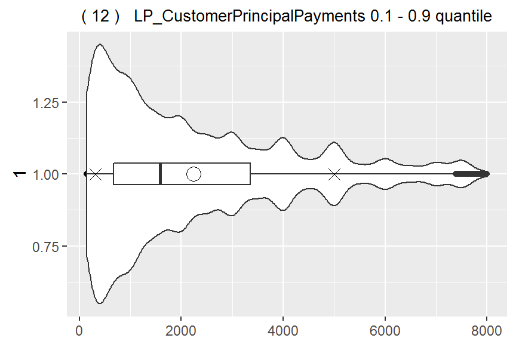

```
## [1] "7   100 %  ---  LP_InterestandFees"
##     Min.  1st Qu.   Median     Mean  3rd Qu.     Max.
##    -2.35   287.20   715.90  1092.00  1477.00 15620.00
```

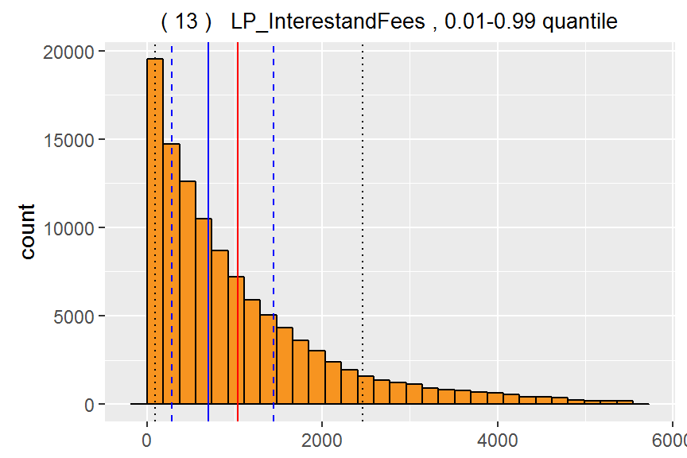

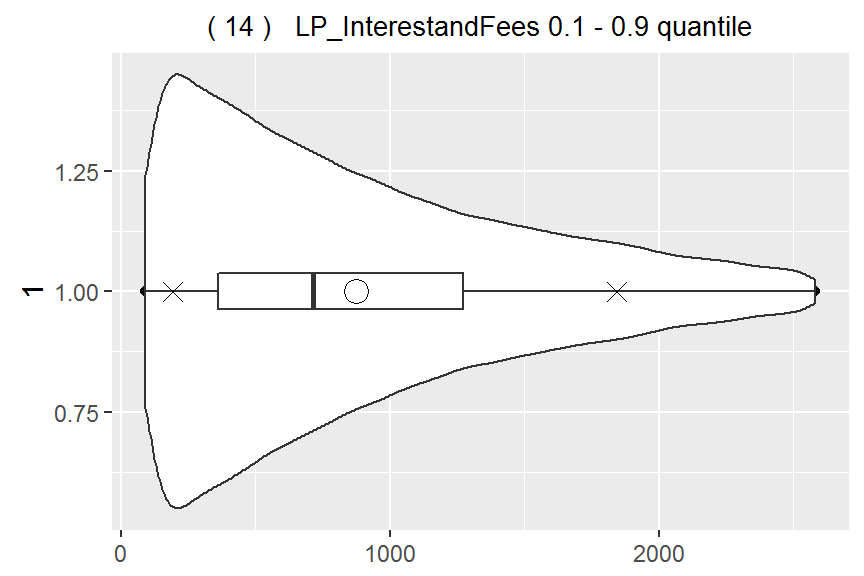

As expected, loan origination and close date are bimodal. Showed plots do not show anything suspicious, except monthly loan payment, which has minumum at 0, which is weird.

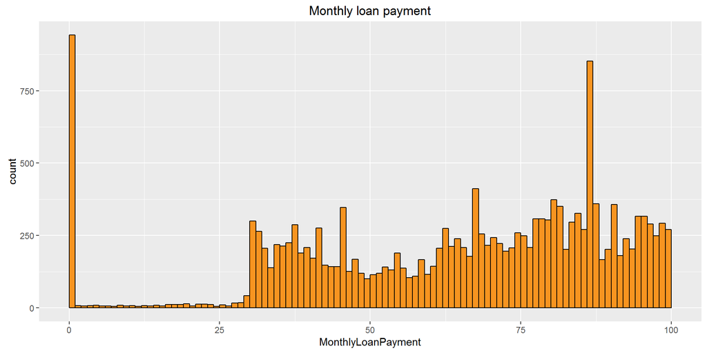

I think, that it would better to manually calculate monthly payment and compare it.

$\large{Monthly payment = Principal * \frac{i * \left( 1 + i \right) ^ n} {\left( 1 + i \right) ^ n - 1}}$

Summary of monthly payment difference:

```
##      Min.   1st Qu.    Median      Mean   3rd Qu.      Max.      NA's
## -266.4000   -0.0026    0.0000    2.3770    0.0028 1359.0000         7
```

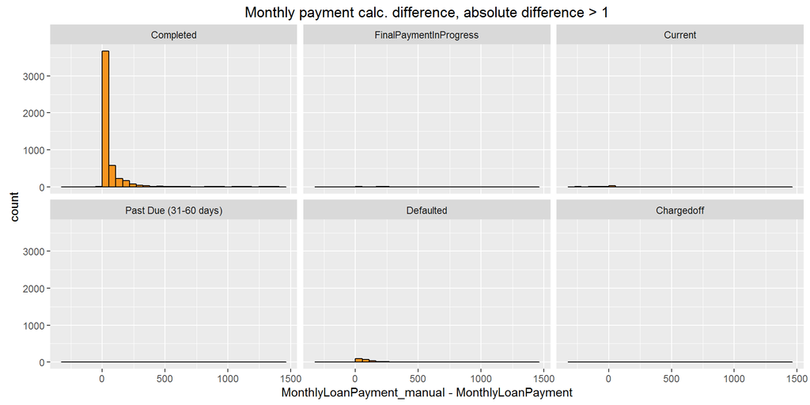

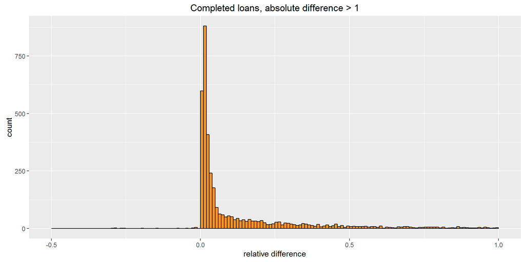

Above charts tell us, that 95.39 percent of all loans have correctly calculated monthly loan payment (have difference between manually calculated <-1, 1>). Altough, some loans have very big difference and most of them are in completed status. I will retain them in the dataset, but for neccessary calculations, I will use manually calculated monthly payment.

#### Target variable

Which variable express borrower’s ability to repay loan? According to loan status, we have 2 opposite sides. Succesfully completed loans and loans with final payment in progress, and on the other side defaulted and charged off loans. One way how to find differences in input variables, might be to compare these 2 subsets with statistical tests. Target variable, which I would like to find or create, should reflect and emphasize differrence between these 2 subsets. It should be a continuous measure, which is rid of the time factor and provide same information across whole dataset, if possible.

Variables, which may contain needed information, are:

- LoanCurrentDaysDelinquent
- LoanStatus
- ProsperPaymentsLessThanOneMonthLate
- ProsperPaymentsOneMonthPlusLate
- OnTimeProsperPayments
- LP_InterestandFees

LoanCurrentDaysDelinquent variable is valid for outstanding loans and shows number of days, which is borrower late with last monthly payment. ProsperPaymentsLessThanOneMonthLate, ProsperPaymentsOneMonthPlusLate and OnTimeProsperPayments are valid only for listings of borrowers, which had at least 1 loan before. LP_InterestandFees is amount paid by borrower covering the interest and fees part of repayable amount.

Let’s examine completed loans closer.

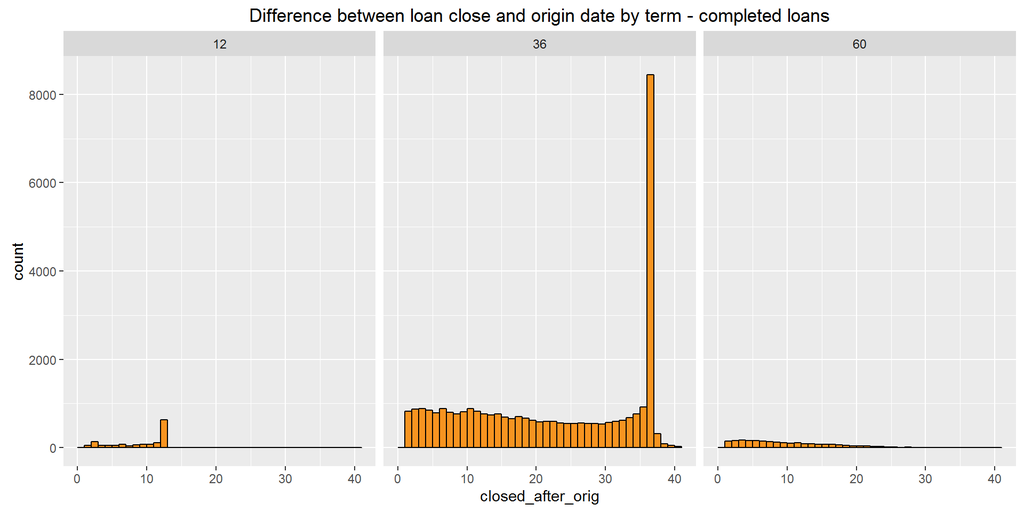

From above plot we see, that most of completed loans were repaid earlier than original term, specially loans with 60 months term. I did not expect such big number of loans repaid so early. I think, that it might be possible, that some borrowers repaid loan fast for much lower interest only to get for example better score and lower iterest rate as existing clients, or borrow higher amount.

Number of not closed charged off, completed and defaulted loans: 0

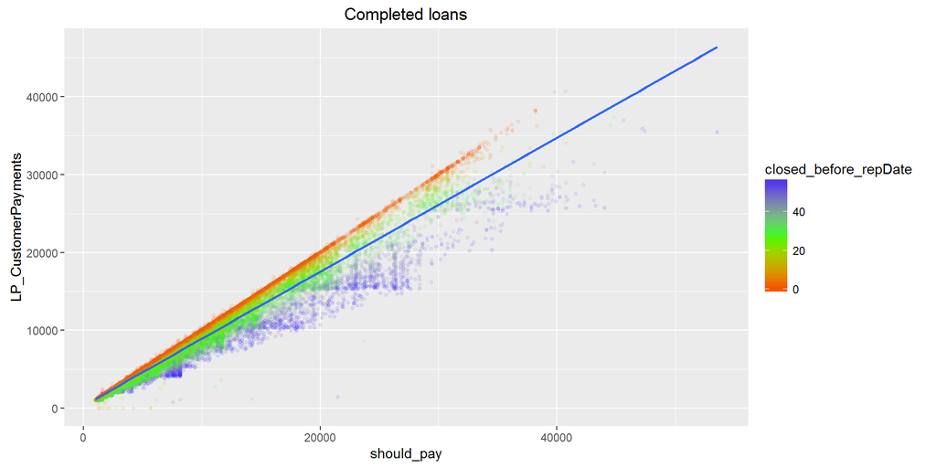

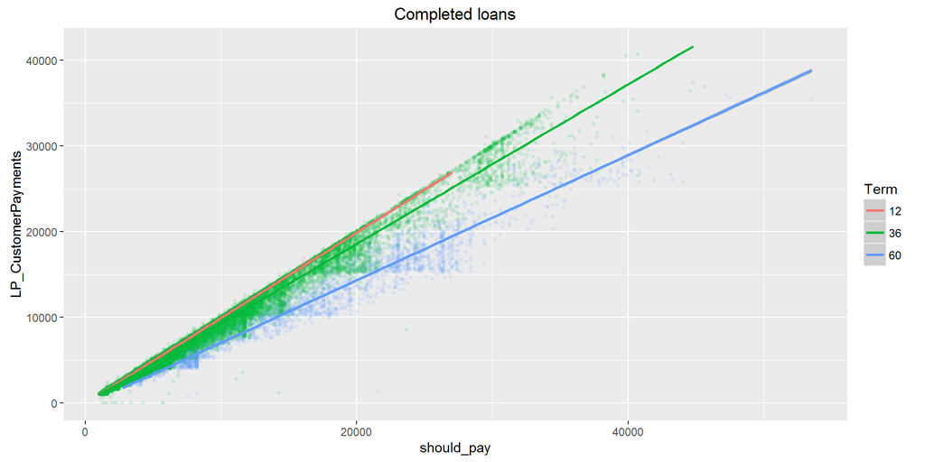

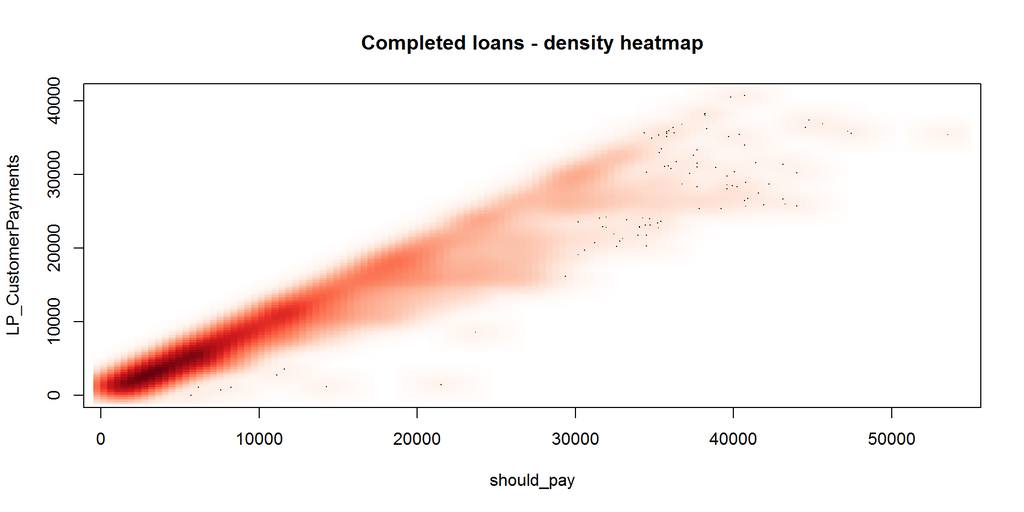

```
## [1] "1   100 %  ---  difference_from_origAmount"
##     Min.  1st Qu.   Median     Mean  3rd Qu.     Max.     NA's
## -50350.0 -11610.0  -4184.0  -7180.0   -724.7   1548.0        7
```

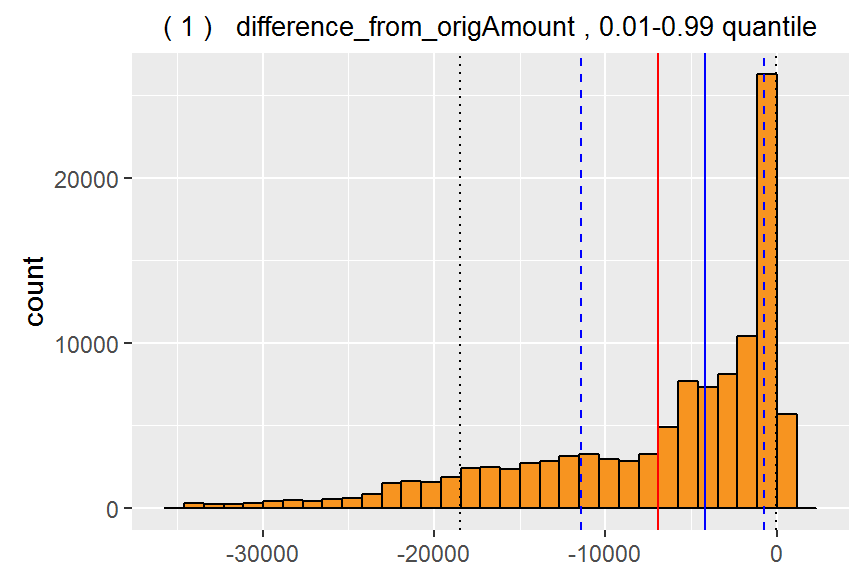

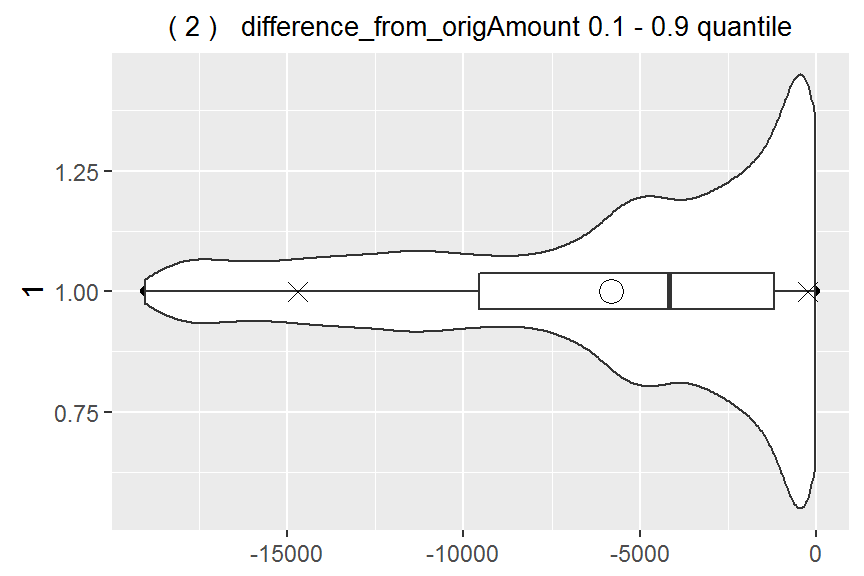

From above plots we see, that borrowers, which repaid their loans earlier did not have to pay full repayable amount. Overpaid loans are rare, and the overpaid amount should contain only late fees. But for loans repaid earlier and are underpaid, how much money is enough to complete the loan? If the borrower had some late payments, cah I get information about late fees?